```python
import numpy as np

from example_models import get_phase_plane
from mxlpy import plot
from mxlpy.simulator import Simulator
from mxlpy.types import unwrap
```

# Stability analysis

*mxlpy* offers routines to easily visualise the stability of the model over a wide range of parameters.

`plot.trajectories2d` shows the vector field depending on the values of two `variables` as a quiver plot.

```python
_ = plot.trajectories_2d(
    get_phase_plane(),
    x1=("s1", np.linspace(0, 2, 20)),
    x2=("s2", np.linspace(0, 2, 20)),
)
```

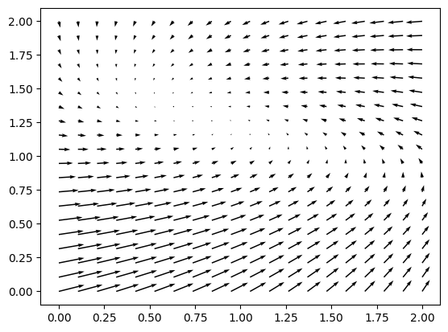

As always, `plot.trajectories_2d` returns matplotlib `Figure` and `Axes` objects, so you can further customise the plot.  
Below we visualise example trajectories for different initial conditions of the model.

```python
fig, ax = plot.trajectories_2d(
    get_phase_plane(),
    x1=("s1", np.linspace(0, 2, 20)),
    x2=("s2", np.linspace(0, 2, 20)),
)

for s1 in np.linspace(0, 1, 4):
    for s2 in np.linspace(0, 2, 4):
        c = unwrap(
            Simulator(get_phase_plane(), y0={"s1": s1, "s2": s2})
            .simulate(1.5)
            .get_result()
        ).variables
        ax.plot(c["s1"], c["s2"])
```

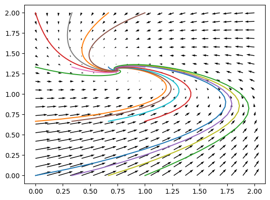